# Practical Machine Learning

Ruben Garzon

Sep 2014

### Course Project Write up

We will first download both training and test sets and remove some columns that according to the project do not offer real information to predict the outcome classe. We will also use the caret package to divide the training set into training and test sets with a p=0.75 (75% training, 25% test).  
One of the things we have considered when selecting the relevant predictors is what predictors contain valid data in the test dataset provided in the assignment. It is not useful to fit using predictors that have no valid data in the test dataset provided because our target is predicting the outcome for those 20 specific test cases with maximum accuracy.

```r
library(caret)
library(MASS)
library(class)
trainSet <- read.csv("pml-training.csv")
testSet <- read.csv("pml-testing.csv")
bad_idxs<- grep("*timestamp*",names(trainSet))
bad_idxs<- c(bad_idxs,match(c("user_name","new_window","num_window","X"),names(trainSet)))
#We select columns based on the data available in the Test Set
goodCols<- apply(testSet,2, function(x) !any(is.na(x)) )
allSet<-trainSet[,goodCols]
allSet<-allSet[,-bad_idxs]
complete<-na.omit(allSet)
inTrain<-createDataPartition(complete$classe,p=0.75,list=FALSE)
train<-complete[inTrain,]
test<-complete[-inTrain,]
```

In addition, we will prepare the assignment test data set (the one that we need to predict to submit in the assignment) to be evaluated with the different models and also the function to write one file per each one of the 20 predictions.

```r
testSet2<-testSet[,goodCols]
testSet2<-testSet2[,-bad_idxs]

pml_write_files = function(x){
  n = length(x)
  for(i in 1:n){
    filename = paste0("problem_id_",i,".txt")
    write.table(x[i],file=filename,quote=FALSE,row.names=FALSE,col.names=FALSE)
  }
}
```

```r
lda.fit.CV <- lda(classe ~ ., data=train,CV=TRUE)
confusionMatrix(lda.fit.CV$class,train$classe)$overall
```

```
##       Accuracy          Kappa  AccuracyLower  AccuracyUpper   AccuracyNull
##      7.044e-01      6.259e-01      6.970e-01      7.118e-01      2.843e-01
## AccuracyPValue  McnemarPValue
##      0.000e+00     9.851e-155
```

```r
lda.fit <- lda(classe ~ ., data=train,CV=FALSE)
lda.predict <- predict( lda.fit, newdata=test,type='response')
lda.assignment <- predict(lda.fit,newdata=testSet2,type='response')
#this is the prediction of lda for the class exercise dataset
lda.assignment$class
```

```
##  [1] B A B C C E D D A A D A B A E A A B B B
## Levels: A B C D E
```

```r
#this is the correct prediction for the class exercise dataset
#B A B A A E D B A A B C B A E E A B B B
```

```r
qda.fit.CV <- qda( classe ~ ., data=train,CV=TRUE )
confusionMatrix(qda.fit.CV$class,train$classe)$overall
```

```
##       Accuracy          Kappa  AccuracyLower  AccuracyUpper   AccuracyNull
##      8.931e-01      8.650e-01      8.880e-01      8.981e-01      2.843e-01
## AccuracyPValue  McnemarPValue
##      0.000e+00     2.068e-122
```

```r
qda.fit <- qda( classe ~ ., data=train )
qda.predict <- predict( qda.fit, newdata=test,type='response')
confusionMatrix(qda.predict$class,test$classe)$overall
```

```
##       Accuracy          Kappa  AccuracyLower  AccuracyUpper   AccuracyNull
##      8.864e-01      8.566e-01      8.772e-01      8.952e-01      2.845e-01
## AccuracyPValue  McnemarPValue
##      0.000e+00      9.008e-48
```

```r
qda.assignment <- predict(qda.fit,newdata=testSet2,type='response')
qda.assignment$class
```

```
##  [1] A A B A A E D B A A B C B A E E A B B B
## Levels: A B C D E
```

```r
#this is the correct prediction for the class exercise dataset
#B A B A A E D B A A B C B A E E A B B B
```

Finally we will fit a **Random Forest** model using the caret package. We are telling the caret package to use a **5-Fold Cross-Validation** and repeat the process 10 times to compute te estimated out of sample accuracy. After a while, we obtain very good **Accuracy level above the 99%**

```r
ctrl <- trainControl(method="repeatedcv",repeats=10,number=5)
load("rf_fit.rda")
#Uncomment the following lines when running the code, Random Forest will take long to fit the model
#rf_fit <- train(classe~.,data=train,trControl=ctrl,method="rf",proximity=FALSE)
#save(rf_fit, file = "rf_fit.rda")
pred_rf <- predict(rf_fit,test)
confusionMatrix(pred_rf,test$classe)$overall
```

```
##       Accuracy          Kappa  AccuracyLower  AccuracyUpper   AccuracyNull
##         0.9986         0.9982         0.9971         0.9994         0.2845
## AccuracyPValue  McnemarPValue
##         0.0000            NaN
```

```r
answers <- predict(rf_fit,testSet2)
#This is the prediction obtain from the Random Forest
answers
```

```
##  [1] B A B A A E D B A A B C B A E E A B B B
## Levels: A B C D E
```

```r
#This is the correct prediction for the class exercise dataset
#B A B A A E D B A A B C B A E E A B B B
```

We will finally call the function to write the answers to files and submit the correct solutions found using random forest.

```r
pml_write_files(answers)
```

To conclude, we will compare the obtained Accuracy levels with the 3 methods.

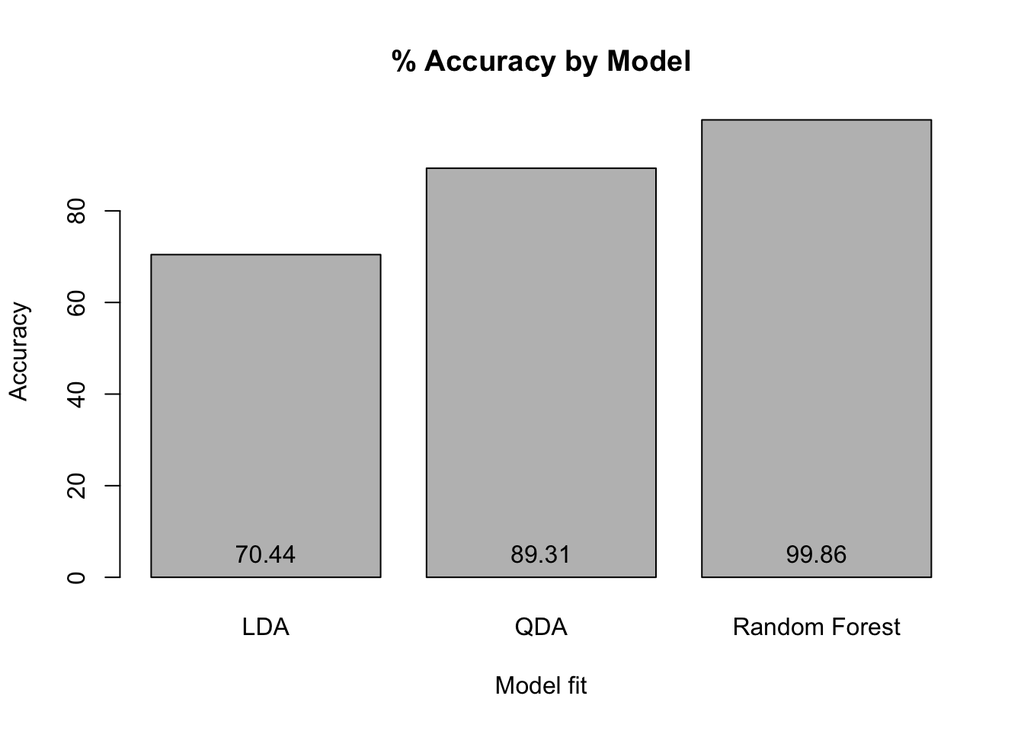